# Bioinformatics Resources Project: Lung Squamous Cell Carcinoma Dataset

Sara Baldinelli, Letizia De Pietri, Roan Spadazzi

08-06-2024

### 1. Load the RData file

The analysis we are going to perform concerns the Lung Squamous Cell Carcinoma Dataset (extracted from the Cancer Genome Atlas), containing 62940 observations, one for each Ensembl ID, having raw expression counts for each sample. Moreover, samples are divided into Cases and Controls. After loading the dataset we start our analysis step-by-step.

#### Load libraries

```r
library(biomaRt)                              # to retrieve data from ensembl
library(tibble)                               # tidyverse dataframes
library(ggplot2)                              # plotting
library(stringr)                              # string manipulation
library(tidyverse)                            # collection of packages
library(edgeR)                                # differential expression analysis
library(clusterProfiler)                      # gene functional annotation
library(org.Hs.eg.db)                         # genome wide annotation (human)
library(MotifDb)                              # position frequency matrices
library(seqLogo)                              # sequence logos from PWMs
library(PWMEnrich)                            # DNA motif scanning + enrichment analysis
library(PWMEnrich.Hsapiens.background)        # background objects for H. sapiens
library(pathview)                             # visualize pathways
library(igraph)                               # create, visualize, modify networks
library(dplyr)                                # data manipulation, filtering
library(TxDb.Hsapiens.UCSC.hg38.knownGene)    # human annotation hg38
library(BSgenome.Hsapiens.UCSC.hg38)          # human genomic sequences hg38
library(GenomicFeatures)                      # transcript genomic locations
library(enrichplot)                           # interpret functional enrichment
library(ggnewscale)                           # plotting with multiple scales
library(dendextend)                           # dendrograms
library(annotate)                             # annotation
```

### 2. Extract only protein coding genes

```r
# setting up ensembl
ensembl <- useMart(biomart="ensembl",dataset="hsapiens_gene_ensembl")

# getting data from ensembl
query1 <- getBM(attributes=c("ensembl_gene_id",
                              "external_gene_name",
                              "gene_biotype",
                              "start_position",
                              "end_position",
                              "chromosome_name",
                              "strand",
                              "description",
                              "version"),
                filters=c("ensembl_gene_id"),
                # get only the ensembl IDs of the dataset
                values=list(r_anno_df$ensembl_gene_id),
                mart = ensembl)

# filtering data by protein coding genes
query1_pc <- query1[which(query1$gene_biotype=="protein_coding"),]
ensembl_gene_id <- query1_pc$ensembl_gene_id
pc <- as.data.frame(ensembl_gene_id)
# apply the filter to r_anno and raw_counts
r_anno_pc <- merge(pc, r_anno_df, by="ensembl_gene_id")
raw_counts_pc <- as.data.frame(raw_counts_df)
ensembl_gene_id <- row.names(raw_counts_pc)
raw_counts_pc$ensembl_gene_id <- ensembl_gene_id
raw_counts_pc <- merge(pc, raw_counts_pc, by="ensembl_gene_id")
raw_counts_pc <- column_to_rownames(raw_counts_pc, var = "ensembl_gene_id")
r_anno_pc <- column_to_rownames(r_anno_pc, var = "ensembl_gene_id")
```

Pre-filtering:

```r
dim(r_anno_df)
```

```
## [1] 62940     3
```

Post-filtering:

```r
dim(r_anno_pc)
```

```
## [1] 22142     2
```

The query is filtered by protein coding genes and consequently updating *r_anno* and the raw counts accordingly. The dataframe is reduced to ~35% of its original size.

### 3. Differential expression analysis

#### 3.1. Pre-processing

```r
# filter by raw count
filter_vec <- apply(raw_counts_pc,1,
    function(y) max(by(y, c_anno_df$condition, function(x) sum(x>=20))))

# filter by presence
filter_counts_pc <- raw_counts_pc[filter_vec>=5,]
filter_anno_pc <- r_anno_pc[rownames(filter_counts_pc),]
dim(filter_anno_pc)
```

```
## [1] 17539     2
```

This step filters raw counts retaining only genes with raw count > 20 and present in at least 5 Cases OR 5 Controls. This further filtering reduces the dataset size to ~27% of its original size.

```r
# Data Normalization
edge_c <- DGEList(counts=filter_counts_pc,group=c_anno_df$condition,samples=c_anno_df,genes=filter_anno_pc)
edge_n <- calcNormFactors(edge_c,method="TMM")
```

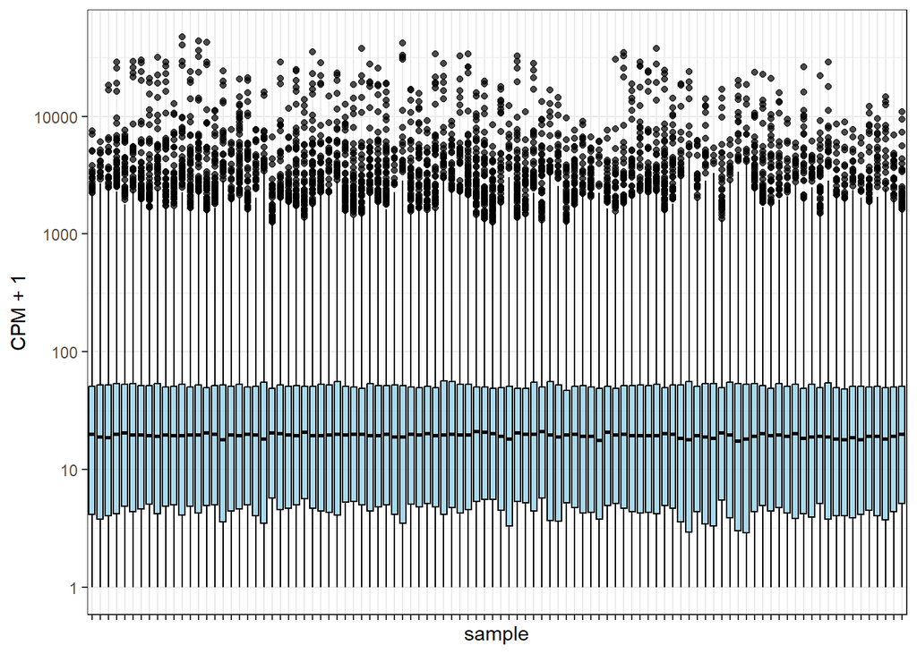

```r
# Counts Table
cpm_table <- as.data.frame(round(cpm(edge_n),2))

# Boxplot distribution of gene expression signals post normalization
long_cpm_df <- gather(cpm_table, key = "sample", value = "CPM")

ggplot(data=long_cpm_df,aes(sample,CPM+1)) +
   geom_boxplot(colour="black",fill="skyblue",alpha=0.7)+
   theme_bw()+
   scale_y_log10() +
   theme(axis.text.x = element_blank())
```

The *cpm_table* contains the counts per million for each sample and distributed across all Ensembl Gene IDs. From the boxplots we can see the effects of normalization, with still some outliers visible, but having the medians aligned around the same values (~18).

#### 3.2. Cases vs Controls Visualization

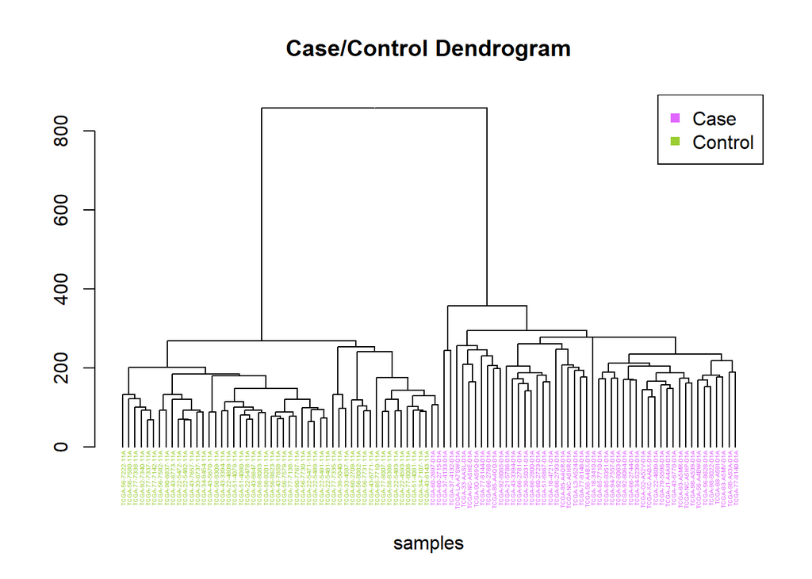

```r
# Plot dendrogram
clu_data <- t(scale(t(cpm_table)))
dd <- dist(t(clu_data), method = "euclidean")
hc <- hclust(dd, method = "ward.D2")
dend <- as.dendrogram(hc)

color <- ifelse(c_anno_df$condition == "case", "mediumorchid1",
                ifelse(c_anno_df$condition == "control", "olivedrab3", NA))
labels_colors(dend) <- color[order.dendrogram(dend)]
dend <- dend %>% set("labels_cex", 0.3)

plot(dend, main = "Case/Control Dendrogram",
     xlab='samples')
legend(x = 'topright',
       legend = c("Case", "Control"),
       pch = c(15, 15),
       col = c("mediumorchid1", "olivedrab3"))
```

From the dendrogram we see the distinction between two main clusters, one for the Cases and the other for the Controls, though we notice that two Case samples (*TCGA-60-2697-01A* and *TCGA-60-2715-01A*) are seemingly misclassified. The method used to compute distances between samples is the Ward’s one.

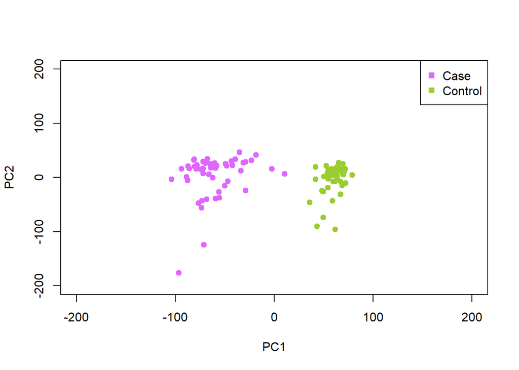

```r
# principal component analysis
data.matrix <- cpm_table
data.PC <- prcomp(t(data.matrix),scale.=TRUE)
# color cases in mediumorchid1, controls in olivedrab3
color <- ifelse(c_anno_df$condition == "case", "mediumorchid1", ifelse(c_anno_df$condition == "control", "olivedrab3", NA))
plot(data.PC$x[,1:2],xlim=c(-200,200),ylim=c(-200,200),col=color,pch=19)
legend(x = 'topright',
       legend = c("Case", "Control"),
       pch = c(15, 15),
       col = c("mediumorchid1", "olivedrab3"))
```

The two clusters are visible also after performing principal component analysis: we can clearly see that they correspond to the Cases in pink and Controls in green. The two cases “outliers” seen before are between the two clusters (near ~0,0).

#### 3.3. Volcano Plot

```r
# define the experimental design matrix (cases vs controls)
design <- model.matrix(~0+group, data=edge_n$samples)
colnames(design) <- levels(edge_n$samples$group)
rownames(design) <- edge_n$samples$sample

# calculate dispersion and fit with edgeR
edge_d <- estimateDisp(edge_n,design)  # maximize likelihood
edge_f <- glmQLFit(edge_d,design)      # fit a generalized linear model
contr <- makeContrasts("case-control", levels=design)

# fit the model with generalized linear models
edge_t <- glmQLFTest(edge_f,contrast=contr)
DEGs <- as.data.frame(topTags(edge_t, n=20000, p.value = 0.01, sort.by = "logFC"))
DEGs$class <- "="                                        # not-DE
DEGs$class[which(DEGs$logCPM>1&DEGs$logFC>1.5)] = "+"    # up-regulated
DEGs$class[which(DEGs$logCPM>1&DEGs$logFC<(-1.5))] = "-" # down-regulated
DEGs <- DEGs[order(DEGs$logFC,decreasing = T),]

head(DEGs, n=3)     # shows the first 3 rows of the differentially expressed genes
```

```
##                 external_gene_name length    logFC   logCPM        F
## ENSG00000267978            MAGEA9B   5806 10.84396 3.209475 213.2887
## ENSG00000123584             MAGEA9   5807 10.69339 3.110248 214.7752
## ENSG00000104371               DKK4   3166 10.65399 4.317680 148.3996
##                       PValue          FDR class
## ENSG00000267978 2.039206e-25 2.438011e-24     +
## ENSG00000123584 9.633511e-26 1.186532e-24     +
## ENSG00000104371 1.164143e-24 1.263484e-23     +
```

The DEGs (differentially expressed genes) object contains, for each Ensembl gene ID, its external gene name, the length of the spanned region, the logarithm of the Fold Change (measuring the change in expression levels), the logarithm of the Counts per Million, the F statistic value and its matched p-value representing statistical significance together with the False Discovery Rate and the corresponding DE class (+/-/=).

```r
table(DEGs$class)   # shows how many up +, down - regulated genes and the = ones
```

```
##
##    -    +    =
## 1629 1504 9884
```

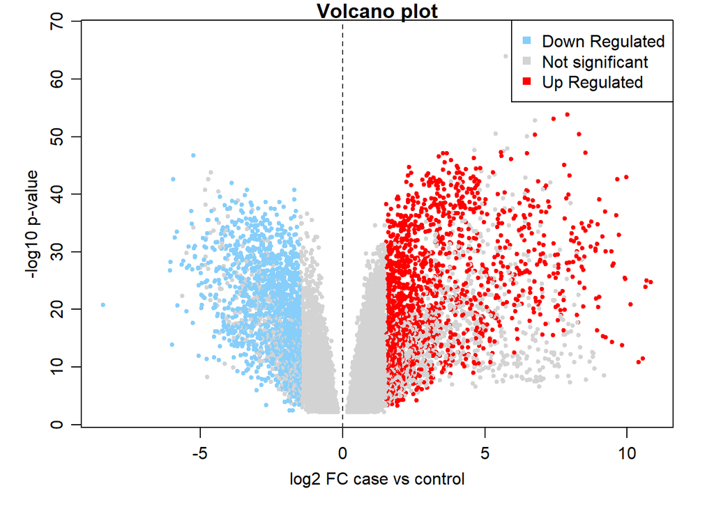

```r
# Display a Volcano plot of the results:
input_df <- DEGs
xlabel <- "log2 FC case vs control"
ylabel <- "-log10 p-value"

par(fig=c(0,1,0,1), mar=c(4,4,1,2), mgp=c(2, 0.75, 0))
plot(input_df$logFC, -log(input_df$PValue,base=10),xlab=xlabel, ylab=ylabel,
     col=ifelse(input_df$class=="=","lightgrey",ifelse(input_df$class=='-', 'lightskyblue', 'red')),
     pch=20, frame.plot=TRUE, cex=0.8, main="Volcano plot")
legend(x = 'topright',
       legend = c("Down Regulated", "Not significant", "Up Regulated"),
       pch = c(15, 15, 15),
       col = c("lightskyblue", "lightgrey", "red"))
abline(v=0,lty=2,col="grey20")
```

From the volcano plot we can see highlighted the down and up regulated genes (in blue and red), respectively with Fold Changes < -1.5 and > 1.5. The ones classified as not significant (in grey) either have low Fold Changes or do not have enough reads mapped to the region (logCPM < 1) or statistical significance (p-value cutoff of 0.01).

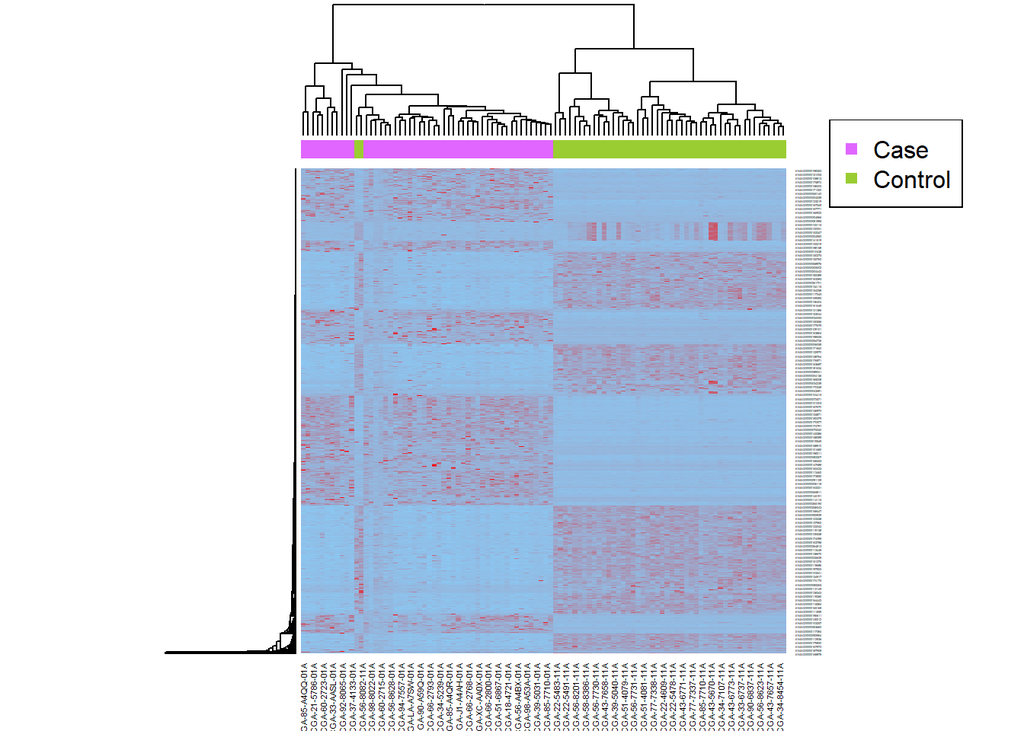

```r
# heatmap
DEGs <- rownames_to_column(DEGs, var = "ensembl_gene_id")
# get only the +/- regulated genes
filtered_DEGs <- as.matrix(cpm_table[which(rownames(cpm_table)%in%DEGs$ensembl_gene_id[which(DEGs$class!="=")]),])
pal <- c("lightskyblue","red")
pal <- colorRampPalette(pal)(100)
heatmap(filtered_DEGs, ColSideColors = color,cexCol = 0.5,margins = c(4,4),col=pal,cexRow = 0.2)
legend(x = 'topright',
       legend = c("Case", "Control"),
       pch = c(15, 15),
       col = c("mediumorchid1", "olivedrab3"))
```

```r
## Export differentially expressed genes in a text file (+/-)
up_DEGs <- DEGs[which(DEGs$class=="+"),]
down_DEGs <- DEGs[which(DEGs$class=="-"),]
```

### 4. Gene set enrichment analysis

#### 4.1. Up-regulated genes

Enrichment based on Biological Processes

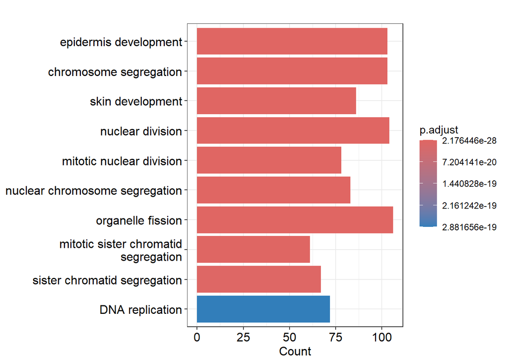

```r
# Gene Ontology enrichment analysis (Biological Processes)
upGO_BP <- enrichGO(gene = up_DEGs$external_gene_name,
                   OrgDb = org.Hs.eg.db,
                   keyType = 'SYMBOL',
                   ont = "BP",
                   pAdjustMethod = "BH",
                   pvalueCutoff = 0.05,
                   qvalueCutoff = 0.05)

# Visualize the top 10 enriched terms with a barplot
barplot(upGO_BP,showCategory=10)
```

From the results we can see that terms related to either the M-phase of the cell cycle (like mitotic nuclear division, chromosome segregation…) or epidermis development are enriched in the up-regulated DEGs. This suggests us that the cell cycle in tumor cells, specifically during the mitotic phase, is altered. Regarding the epidermis development, it has been shown in the literature that the epidermal growth factor (EGF) plays a key role in lung cancer progression (Liu TC et al., 2017).

Enrichment based on Molecular Functions

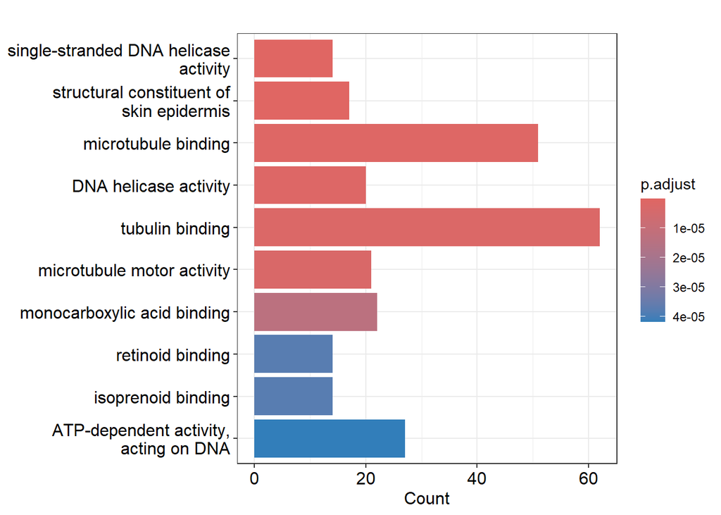

```r
# Gene Ontology enrichment analysis (Molecular Functions)
upGO_MF <- enrichGO(gene = up_DEGs$external_gene_name,
                   OrgDb = org.Hs.eg.db,
                   keyType = 'SYMBOL',
                   ont = "MF",
                   pAdjustMethod = "BH",
                   pvalueCutoff = 0.05,
                   qvalueCutoff = 0.05)

# Visualize the top 10 enriched terms with a barplot
barplot(upGO_MF,showCategory=10)
```

Some of these molecular functions are coherently related to the previously mentioned biological processes. For example, microtubule and tubulin binding are involved in the mitotic spindle formation during mitosis.

Pathway Enrichment (KEGG)

```r
# Get the entrez gene IDs needed for KEGG pathway enrichment
query_up <- getBM(attributes=c("entrezgene_id"),
                filters=c("ensembl_gene_id"),
                values=list(up_DEGs$ensembl_gene_id),
                mart = ensembl)
# KEGG pathway enrichment analysis
up_WP <- enrichKEGG(gene = query_up$entrezgene_id,
                    organism = 'human',
                    pvalueCutoff = 0.05,
                    qvalueCutoff = 0.1)

WP_up_enrich_terms <- data.frame(Pathway=up_WP@result[["Description"]], P.value=up_WP@result[["pvalue"]])
```

```r
head(WP_up_enrich_terms, n=10)
```

```
##                                         Pathway      P.value
## 1                                    Cell cycle 1.130035e-16
## 2                               DNA replication 2.879125e-07
## 3  Metabolism of xenobiotics by cytochrome P450 6.253750e-07
## 4                         p53 signaling pathway 1.094300e-06
## 5      Pentose and glucuronate interconversions 2.076853e-06
## 6               Drug metabolism - other enzymes 4.035482e-06
## 7             Drug metabolism - cytochrome P450 1.244245e-05
## 8                            Retinol metabolism 1.778416e-05
## 9                      ECM-receptor interaction 1.846030e-05
## 10                       Glutathione metabolism 3.584168e-05
```

As expected the most enriched pathways concern the cell cycle and DNA replication. Additionally, it is interesting to note the presence of the p53 signaling pathway, known to be involved in cancer progression, and pathways related to cytochrome P450, key enzymes in cancer formation and treatment (Rodriguez-Antona C et al., 2006).

#### 4.2. Down-regulated genes

Enrichment based on Biological Processes

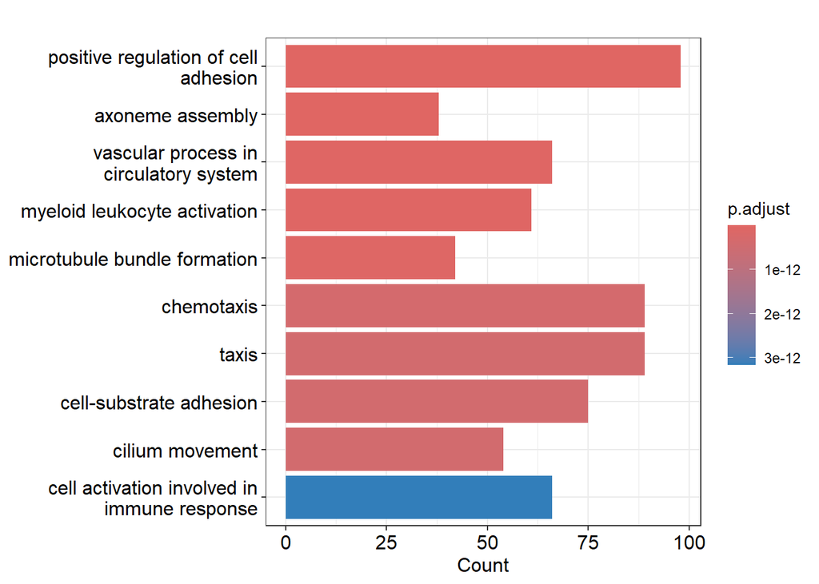

```r
# Gene Ontology enrichment analysis (Biological Processes)
downGO_BP <- enrichGO(gene = down_DEGs$external_gene_name,
                   OrgDb = org.Hs.eg.db,
                   keyType = 'SYMBOL',
                   ont = "BP",
                   pAdjustMethod = "BH",
                   pvalueCutoff = 0.05,
                   qvalueCutoff = 0.05)

# Visualize the top 10 enriched terms with a barplot
barplot(downGO_BP,showCategory=10)
```

From the barplot we can see that the most significantly enriched biological process regards positive regulation of cell adhesion: if misregulated this process can contribute to tumor metastasis (Thapa N et al., 2023).

Enrichment based on Molecular Functions

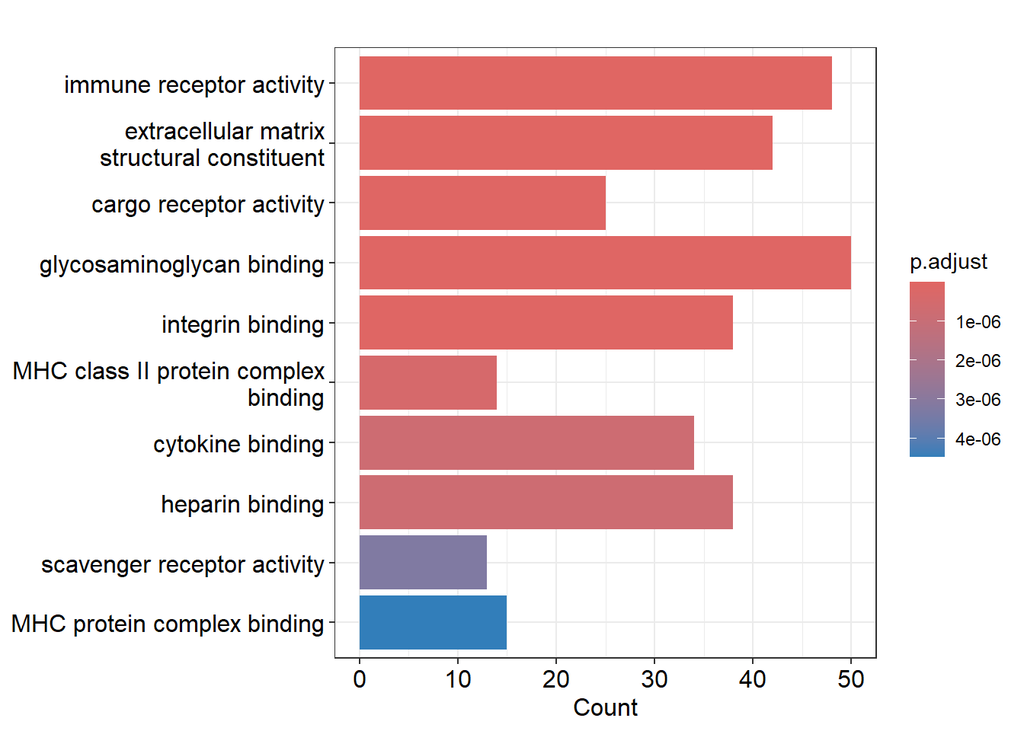

```r
# Perform Gene Ontology enrichment analysis (Molecular Functions)
downGO_MF <- enrichGO(gene = down_DEGs$external_gene_name,
                   OrgDb = org.Hs.eg.db,
                   keyType = 'SYMBOL',
                   ont = "MF",
                   pAdjustMethod = "BH",
                   pvalueCutoff = 0.05,
                   qvalueCutoff = 0.05)

# Visualize the top 10 enriched terms with a barplot
barplot(downGO_MF,showCategory=10)
```

The down-regulation of various types of immune cells (and in our case the immune receptor activity) indicates an impaired immune response, in accordance with general cancer microenvironment.

Pathway Enrichment (KEGG)

```r
# Get the entrez gene IDs needed for KEGG pathway enrichment
query_down <- getBM(attributes=c("ensembl_gene_id","entrezgene_id"),
                 filters=c("ensembl_gene_id"),
                 values=down_DEGs$ensembl_gene_id,
                 mart = ensembl)
# KEGG pathway enrichment analysis
down_WP <- enrichKEGG(gene = query_down$entrezgene_id,
                    organism = 'human',
                    pvalueCutoff = 0.05,
                    qvalueCutoff = 0.1)

WP_down_enrich_terms <- data.frame(Pathway=down_WP@result[["Description"]], P.value=down_WP@result[["pvalue"]])
head(WP_down_enrich_terms, n=10)
```

```
##                                Pathway      P.value
## 1  Complement and coagulation cascades 8.107260e-16
## 2      Staphylococcus aureus infection 4.715338e-13
## 3              Cell adhesion molecules 7.746507e-12
## 4           Hematopoietic cell lineage 5.799980e-11
## 5                               Asthma 6.125648e-09
## 6                              Malaria 8.575834e-09
## 7                    Viral myocarditis 2.508464e-08
## 8                        Leishmaniasis 4.801034e-08
## 9                 Rheumatoid arthritis 1.590091e-07
## 10          Osteoclast differentiation 2.095743e-07
```

The most enriched down-regulated pathway is the Complement and coagulation cascades one: the complement system is known to participate in adaptive immunity. This may be the consequence of either the tumor condition of the patients or the presence of a Staphylococcus aureus infection down-regulation, detected as the second most enriched pathway. Furthemore, the down-regulation of cell adhesion molecules is coherent with the previously described biological function (regulation of cell adhesion).

### 5. Pathway Visualization (up-regulated)

```r
# Plot the pathway with DEGs (+)
logFC <- up_DEGs$logFC
names(logFC) <- up_DEGs$ensembl_gene_id
```

[output not shown]

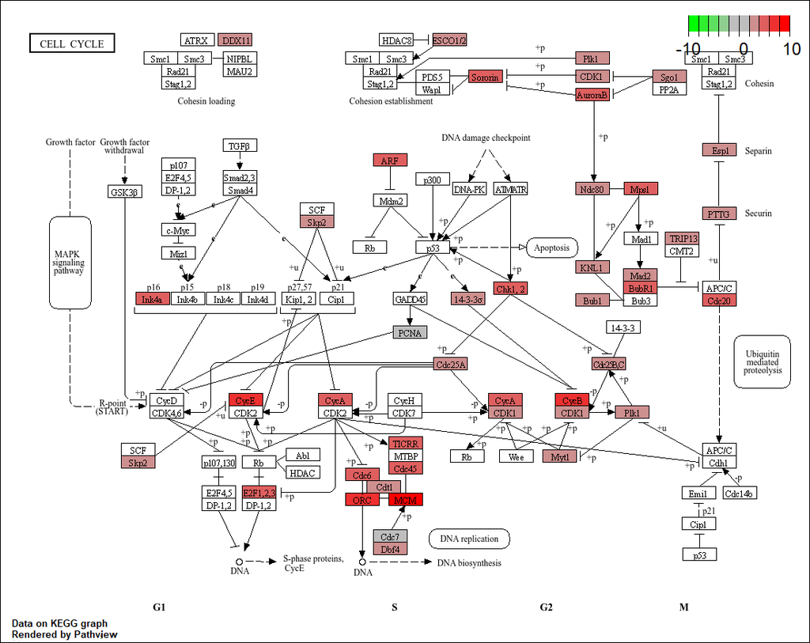

pathview_cell_cycle

```r
# Saves pathway in an image
pathview(gene.data = logFC,
         gene.idtype = "ENSEMBL",
         pathway.id = "hsa04110",
         species = "human",
         limit = list(gene=10, cpd=1))
```

Here we have the visualization of the KEGG cell cycle pathway, with genes colored by Fold Change based on their intensity. Coherently to what we mentioned before, the majority of the up-regulated genes are found in the last phases of the cell cycle (G2/M) and also during the S phase (related to DNA replication). Some genes can be taken individually for further analysis: for example, the up-regulation of the MCM gene has been documented to be associated to cancer metastasis and cell proliferation (Si Yu et al., 2020).

### 6. Identify which TFs have enriched scores in the promoters of up-regulated genes

```r
# get the references
txdb <- TxDb.Hsapiens.UCSC.hg38.knownGene
genome <- BSgenome.Hsapiens.UCSC.hg38
entrez_ids_up <- unique(query_up$entrezgene_id)
# get 500bp nucleotide sequences upstream
genes_gr <- genes(txdb, columns = c("gene_id"), filter = list(gene_id = entrez_ids_up))
promoters_gr <- promoters(genes_gr, upstream = 500, downstream = 0)
promoter_seqs <- getSeq(genome, promoters_gr)

# find enriched TFs by affinity score
data(PWMLogn.hg19.MotifDb.Hsap)
enriched_TFs <- motifEnrichment(promoter_seqs,PWMLogn.hg19.MotifDb.Hsap,score = "affinity")
```

```
## Calculating motif enrichment scores ...
```

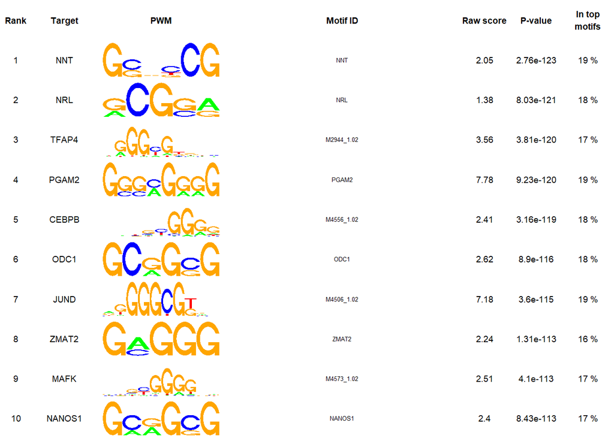

```r
report = groupReport(enriched_TFs)

# plot top 10 motifs
plot(report[1:10], fontsize=7, id.fontsize=5)
```

These are the 10 Transcription Factors (TFs) whose motifs have the most enriched scores in the promoters of all our up-regulated genes. For each TF we have its corresponding name and motif visualized through a sequence logo, the raw score calculated using the Positional Weight Matrix (PWM), the corresponding statistical significance (p-value) and the percentage of sequences in which the motif is found.

### 7. Motif Enrichment

Selection of one TF and computation of the empirical distribution scores for all PWMs, then setting a threshold cutoff of 99.75%.

```r
mdb.human = subset(MotifDb, organism=='Hsapiens' & geneSymbol=="NRL") # select a motif (NRL)
PWM = toPWM(as.list(mdb.human))                                       # get the Positional Weight Matrices
names(PWM) = sapply(names(PWM),function(x) strsplit(x,"-")[[1]][3])
ecdf = motifEcdf(PWM,organism = "hg19",quick=TRUE)                    # empirical distribution
thresholds <- sapply(names(ecdf), function(el) {
  log2(quantile(ecdf[[el]], 1 - 0.0025))                              # set the threshold of 0.9975
})
thresholds
```

```
##        M5689_1.02.99.75% NRL_HUMAN.H10MO.D.99.75%         secondary.99.75%
##                 5.599083                 5.172561                 5.172561
##               NRL.99.75%               NRL.99.75%               NRL.99.75%
##                 7.159066                 7.159066                 7.159066
##               NRL.99.75%               NRL.99.75%  NRL.SwissRegulon.99.75%
##                 7.159066                 7.159066                 5.599083
```

These are the threshold cutoffs at 99.75% for each of the PWM distribution of scores. *NRL* (Rank 2) was chosen among the top enriched TFs, having multiple PWMs (9) in MotifDb.

### 8. Pattern Matching

We identify which up-regulated genes have a region in their promoter with binding scores above the computed thresholds for any of the previously selected PWMs.

```r
# pattern matching
matches <- c()
nomatches <- c()
best <- 0            # save best match
best_scores <- 0     # save best match score (raw)

# for each promoter sequence
for (n in 1:length(promoter_seqs)){
  # compute the scores for each motif
  scores = motifScores(promoter_seqs[n], PWM, cutoff=thresholds)
  if (any(scores)>0){                # if any match > 0
    matches <- append(matches,n)     # save it
    if (sum(scores) > best){         # check if best
      best <- n                      # save best
      best_scores <- motifScores(promoter_seqs[n],PWM,cutoff=thresholds,
                                 raw.scores = TRUE)
    }
  }
  else {
    nomatches <- append(nomatches,n)
  }
}

length(matches)
```

```
## [1] 1396
```

```r
length(nomatches)
```

```
## [1] 3
```

```r
entrezlist <- c()
# get entrez ids from list of sequence indices that did not pass the cutoff for any PWM
for (el in nomatches){
  entr <- names(promoter_seqs[el])
  entrezlist <- append(entrezlist,entr)
}
gids <- getSYMBOL(entrezlist, data='org.Hs.eg')  # to get gene symbols from entrez ids
gids
```

```
##   574537     7038     9635
## "UGT2A2"     "TG"  "CLCA2"
```

gids shows the genes (entrez ID with the corresponding gene symbol) that do not have any region in their promoter with binding score above the computed threshold for any of the *NRL* PWMs. Only 3 of the genes are in the gids list, meaning that 99.8% of up-regulated genes promoters have a binding score above the computed threshold.

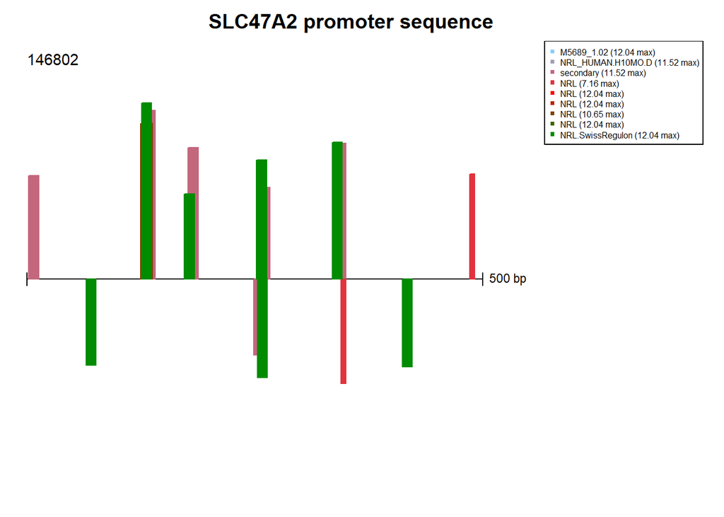

```r
# plotting the best pattern match
bid <- getSYMBOL(promoter_seqs[best]@ranges@NAMES, data='org.Hs.eg')
pal2 <- c("lightskyblue", "red", "green4")
pal2 <- colorRampPalette(pal2)(9)
plotMotifScores(best_scores, legend.cex = 0.5, trans = 0, col=pal2,
                cutoff = thresholds, main=paste(bid, 'promoter sequence'))
```

The plot shows for each promoter position the motif scores drawn as rectangles whose height represents the score itself. Here we show the one having an overall best score across all motifs, annotated as *SLC47A2*. We can see from the different colors that multiple motifs are matched across the 500bp region.

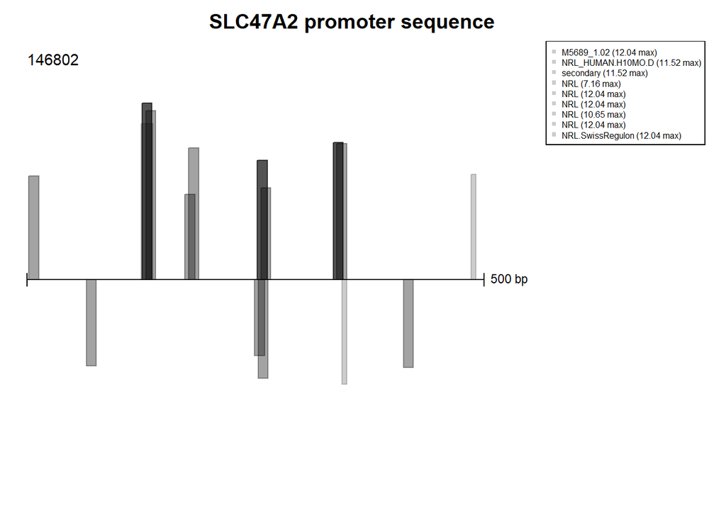

```r
pal3 <- colorRampPalette('black')(9)
plotMotifScores(best_scores, legend.cex = 0.5, trans = 0.8, col=pal3,
                cutoff = thresholds, main=paste(bid, 'promoter sequence'))
```

To better visualize the common regions where multiple motifs are matched, this alternative plot was made. The shade of black is directly proportional to the overlapping of different motifs. From here we can see 3 main “clusters” where motifs having their own PWM are matched in the promoter sequence.

### 9. Use STRING to find PPI interactions

```r
# Save the lists of up and down regulated DEGs
write.table(up_DEGs$ensembl_gene_id, file = "up.txt",row.names=F,col.names=F,sep="\t",quote=F)
write.table(down_DEGs$ensembl_gene_id, file = "down.txt",row.names=F,col.names=F,sep="\t",quote=F)

#links_up <- read.delim("upDEG_STRING.tsv")
#links_down <- read.delim("downDEG_STRING.tsv")
```

The lists were imported, one at a time, on the STRING webtool to visualize protein-protein interactions. Then we exported the found edge lists and imported them in R for further analysis.

### 10. Network Analysis: plot the largest connected component

#### 10.1. Up-regulated Genes

```r
## Network Pre-processing
# Create nodes annotations using biomaRt
nodes_up <-
   getBM(attributes=c("external_gene_name",
                      "ensembl_gene_id",
                      "description",
                      "gene_biotype",
                      "start_position",
                      "end_position",
                      "chromosome_name",
                      "strand"),
         filters=c("ensembl_gene_id"),
         values=up_DEGs[,1],
         mart = ensembl)

# Select relevant columns and remove duplicates
nodes_up <- unique(nodes_up[, c(1, 3:6)])
nodes_up <- nodes_up %>%
  filter(!duplicated(external_gene_name))

# Extract gene names from nodes_up and links_up
df1_names <- nodes_up$external_gene_name
df2_names <- unique(c(links_up$X.node1, links_up$node2))

# Find non-shared gene names
non_shared_names <- df2_names[!df2_names %in% df1_names]

# Filter links_up to include only rows with shared gene names
filtered_df2 <- links_up %>%
  filter(X.node1 %in% df1_names & node2 %in% df1_names)

net_up <- graph_from_data_frame(d = filtered_df2, vertices = nodes_up, directed = FALSE)
```

```r
# Average diameter
mean_distance(net_up, directed=F)
```

```
## [1] 3.249671
```

The average diameter represents the average length of the shortest path between all pairs of nodes in the network. In this case we have a low value of ~3.25 meaning that, on average, it takes 3 nodes to get from a starting node to and ending one. We can deduce that the network is well-connected.

```r
# Clustering coefficient
transitivity(net_up,type="global")
```

```
## [1] 0.6111315
```

The clustering coefficient is a measure of how much nodes tend to cluster together. In this case, the global clustering coefficient (or transitivity) is the ratio of the count of triangles and connected triples in the graph and has a high value of ~0.61. This means that ~60% of the nodes are part of a connected triple.

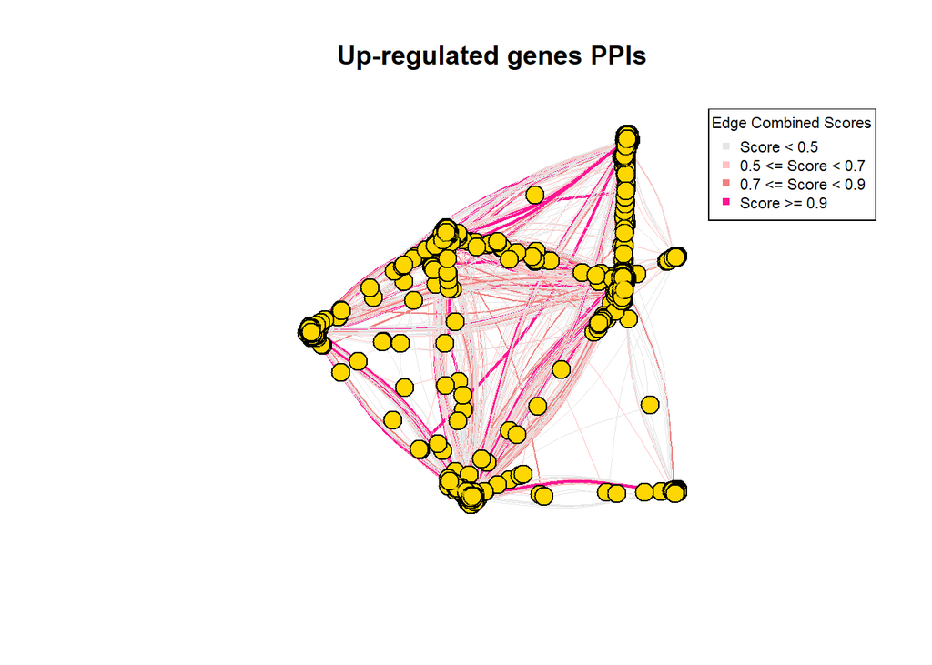

```r
# plotting the largest connected component of the up-regulated genes
c <- components(net_up)
largest_comp <- which.max(c$csize) # in this case = 2
# make a subgraph with the largest connected component
net.c = induced_subgraph(net_up,V(net_up)[which(c$membership==largest_comp)])

# network parameters for plotting

# by edge size
edge_size <- rep(0.00001, length(E(net.c)))
edge_size[which(E(net.c)$combined_score>=0.5)] = 0.05
edge_size[which(E(net.c)$combined_score>=0.7)] = 1
edge_size[which(E(net.c)$combined_score>=0.9)] = 2

# by edge color
edge_col <- rep("grey90", length(E(net.c)))
edge_col[which(E(net.c)$combined_score>=0.5)] = "rosybrown1"
edge_col[which(E(net.c)$combined_score>=0.7)] = "lightcoral"
edge_col[which(E(net.c)$combined_score>=0.9)] = "deeppink1"

plot(net.c,
     edge.width=edge_size,
     edge.color=edge_col,
     vertex.color="gold",
     vertex.size=10,
     vertex.frame.color="black",
     vertex.label.color="gold",
     vertex.label.cex=0.0001,
     edge.curved=0.2,
     main='Up-regulated genes PPIs')
legend(title='Edge Combined Scores',x = 'topright',
       legend = c("Score < 0.5", "0.5 <= Score < 0.7",
                  "0.7 <= Score < 0.9", "Score >= 0.9"),
       pch = c(15, 15, 15, 15),
       col = c("grey90", "rosybrown1", "lightcoral", "deeppink1"),
       cex = 0.7)
```

From this visualization we can see the 1353 nodes (out of the 1489 starting ones) belonging to the largest connected component sub-network. The edges are colored based on their combined scores deriving from STRING (that considers a mixture of experimentally validated interactions, textmining, database annotations etc.) and are colored by ranges of scores. The previously seen high connectivity when looking at the average diameter and global clustering coefficient is visible also here.

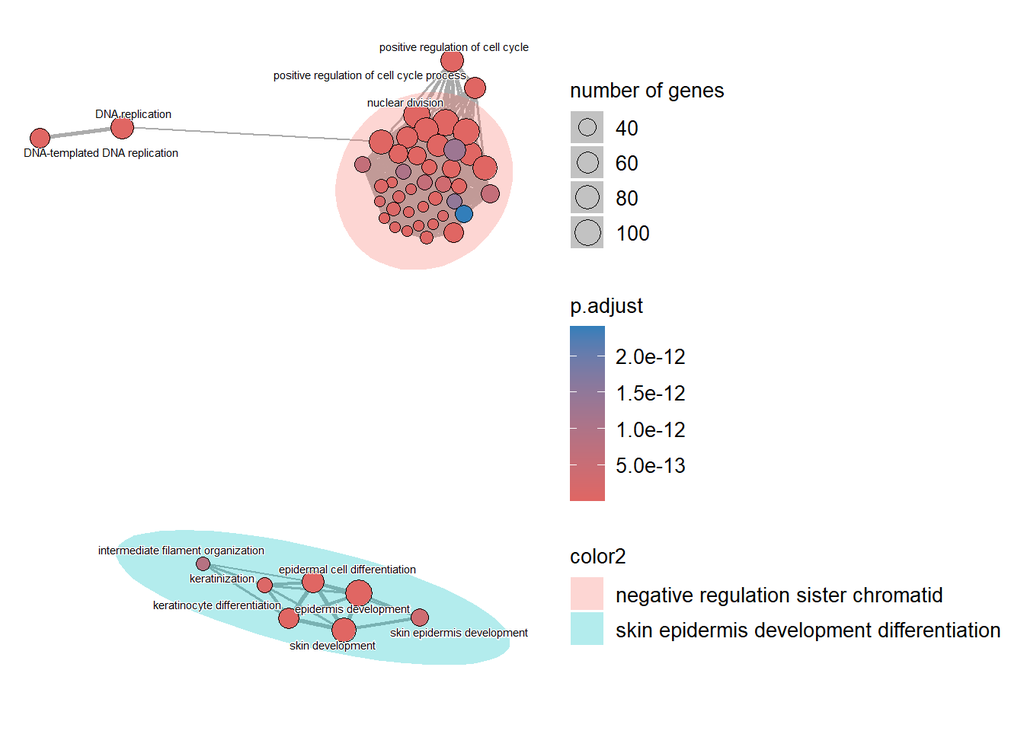

```r
## Gene-set enrichment analysis of the larger connected component
options(ggrepel.max.overlaps = Inf)

# get the Biological Processes of the genes belonging to net.c
ego_BP <- enrichGO(gene = V(net.c)$name,
                   OrgDb = org.Hs.eg.db,
                   keyType = 'SYMBOL',
                   ont = "BP",
                   pAdjustMethod = "BH",
                   pvalueCutoff = 0.05,
                   qvalueCutoff = 0.05)

x <- pairwise_termsim(ego_BP) # similarity matrix
emapplot(x, showCategory=50, cex_label_category = 0.4, cex_line=0.5, repel=TRUE,
         cex_category=0.75, group_category=TRUE, group_legend=TRUE, nCluster=2,
         force=TRUE, ellipse_style='polygon')
```

From the plotted network we can distinguish 2 main enriched pathway-clusters respectively related to the cell cycle and epidermis development plus a pair related to DNA replication. This is coherent with the previous enrichment analysis, showing relevant p-values. Many up-regulated genes that closely interact to one another partake in the cell cycle pathway.

#### 10.2. Down-regulated Genes

```r
## Network Pre-processing
# Create nodes annotations using biomaRt
nodes_down <-
   getBM(attributes=c("external_gene_name",
                      "ensembl_gene_id",
                      "description",
                      "gene_biotype",
                      "start_position",
                      "end_position",
                      "chromosome_name",
                      "strand"),
         filters=c("ensembl_gene_id"),
         values=down_DEGs[,1],
         mart = ensembl)

# Select relevant columns and remove duplicates
nodes_down <- unique(nodes_down[, c(1, 3:6)])
nodes_down <- nodes_down %>%
  filter(!duplicated(external_gene_name))

# Extract gene names from nodes_down and links_down
df1_names <- nodes_down$external_gene_name
df2_names <- unique(c(links_down$X.node1, links_down$node2))

# Find non-shared gene names
non_shared_names <- df2_names[!df2_names %in% df1_names]

# Filter links_down to include only rows with shared gene names
filtered_df2 <- links_down %>%
  filter(X.node1 %in% df1_names & node2 %in% df1_names)

net_down <- graph_from_data_frame(d = filtered_df2, vertices = nodes_down, directed = FALSE)
```

```r
# Average diameter
mean_distance(net_down, directed=F)
```

```
## [1] 3.494746
```

In this case we have an average diameter similar to the previous one, a slightly higher value of ~3.49 meaning that, on average, it takes 3.5 nodes to get from a starting node to and ending one.

```r
# Clustering coefficient
transitivity(net_down,type="global")
```

```
## [1] 0.2945589
```

In this case, the global clustering coefficient has a much lower value of ~0.29, almost half of the previous one. This means that ~30% of the nodes are part of a connected triple, meaning that the down-regulated network is less connected with respect to the other one.

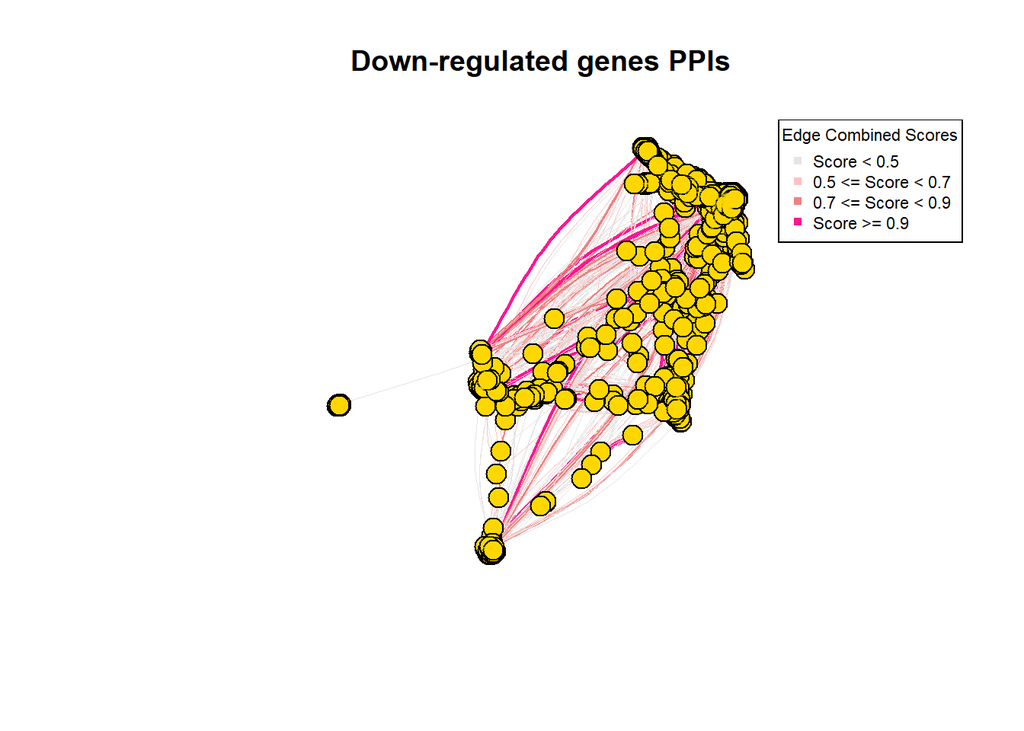

```r
# plotting the largest connected component of the down-regulated genes
c <- components(net_down)
largest_comp <- which.max(c$csize) # in this case = 1
# make a subgraph with the largest connected component
net.c.d = induced_subgraph(net_down,V(net_down)[which(c$membership==largest_comp)])

# network parameters for plotting

# by edge size
edge_size <- rep(0.00001, length(E(net.c.d)))
edge_size[which(E(net.c.d)$combined_score>=0.5)] = 0.05
edge_size[which(E(net.c.d)$combined_score>=0.7)] = 1
edge_size[which(E(net.c.d)$combined_score>=0.9)] = 2

# by edge color
edge_col <- rep("grey90", length(E(net.c.d)))
edge_col[which(E(net.c.d)$combined_score>=0.5)] = "rosybrown1"
edge_col[which(E(net.c.d)$combined_score>=0.7)] = "lightcoral"
edge_col[which(E(net.c.d)$combined_score>=0.9)] = "deeppink1"

plot(net.c.d,
     edge.width=edge_size,
     edge.color=edge_col,
     vertex.color="gold",
     vertex.size=10,
     vertex.frame.color="black",
     vertex.label.color="gold",
     vertex.label.cex=0.0001,
     edge.curved=0.2,
     main='Down-regulated genes PPIs')
legend(title='Edge Combined Scores',x = 'topright',
       legend = c("Score < 0.5", "0.5 <= Score < 0.7",
                  "0.7 <= Score < 0.9", "Score >= 0.9"),
       pch = c(15, 15, 15, 15),
       col = c("grey90", "rosybrown1", "lightcoral", "deeppink1"),
       cex = 0.7)
```

From this visualization we can see the 1450 nodes (out of the 1608 starting ones) belonging to the largest connected component sub-network. The edges are colored based on their combined scores deriving from STRING (that considers a mixture of experimentally validated interactions, textmining, database annotations etc.) and are colored by ranges of scores. The connectivity in this case is lower (~ half the edges of the up-regulated sub-network), and it is visible also when looking at the global clustering coefficient, while maintaining the same average diameter.

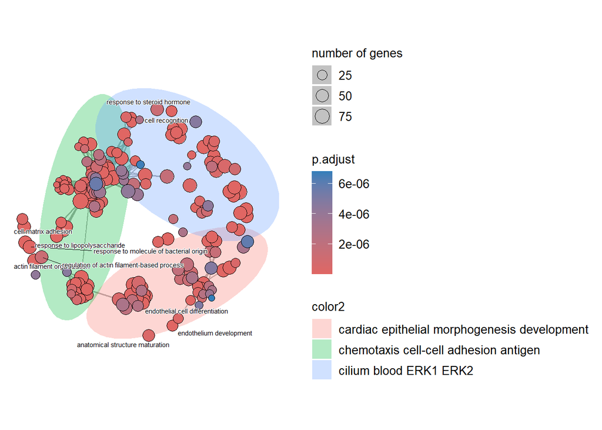

```r
## Gene-set enrichment analysis of the larger connected component
options(ggrepel.max.overlaps = Inf)

ego_BP <- enrichGO(gene = V(net.c.d)$name,
                   OrgDb = org.Hs.eg.db,
                   keyType = 'SYMBOL',
                   ont = "BP",
                   pAdjustMethod = "BH",
                   pvalueCutoff = 0.05,
                   qvalueCutoff = 0.05)

x <- pairwise_termsim(ego_BP)
emapplot(x, showCategory=200, cex_label_category = 0.4, cex_line=0.5, repel=TRUE,
         cex_category=0.75, group_category=TRUE, group_legend=TRUE, nCluster=3,
         force=TRUE, ellipse_style='polygon')
```

From the plotted network we can distinguish 3 main enriched pathway-clusters respectively related to vascular development, chemotaxis-homeostasis and immune system. This is coherent with the previous enrichment analysis, showing relevant p-values (that are higher when compared against the up-regulated ones). In this case the clusters seem to be more “related” to one another, having more evident intersections.

### 11. Conclusions

After running all analysis steps we found some interesting results. Firstly we managed to correctly distinguish between Cases and Controls, both in the dendrograms, in the PCA and finally when directly comparing differentially expressed genes. This led us to export the up and down regulated differentially expressed genes and perform further analyses. By looking at the enrichment of the up-regulated ones we see a prevalence of genes that partake in the cell cycle, suggesting a possible disruption (and up-regulation) that is common in tumors and metastases. On the other hand, looking at the down-regulated ones we see effects on the immune system and chemotaxis, that could be attributable to tumor cells developing mutations to avoid detection. We then performed motif enrichment analysis and found some common motifs in the promoters of our up-regulated genes. Finally, we proceeded by analyzing the networks of the differentially expressed genes and found the largest connected components that spanned the majority of the starting nodes end emap plots confirming our previous enrichment results.